# Отчёт по модулю 1 курса ‘Stepik Введение в Linux’

Дисциплина: Операционные системы

Мацюк Константин Владимирович

Российский университет дружбы народов

2026

## Содержание (1)

- Цель работы
- Задание
- Общая информация
- Как установить Linux
- Осваиваем Linux
- Terminal: основы

## Содержание (2)

- Запуск исполняемых файлов
- Ввод / Вывод
- Скачивание файлов
- Работа с архивами
- Поиск файлов и слов в файлах
- Выводы

# Цель работы

Пройти курс «Введение в Linux» (модуль 1).

# Задание

Выполнить модуль 1.

# Общая информация

Ответил на первый вопрос о названии курса.

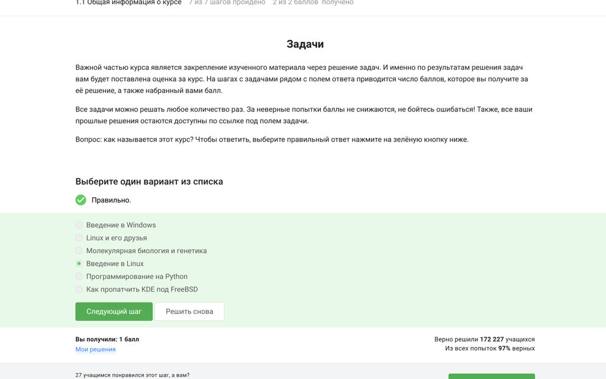

Название курса

Далее — вопрос про общую информацию о курсе.

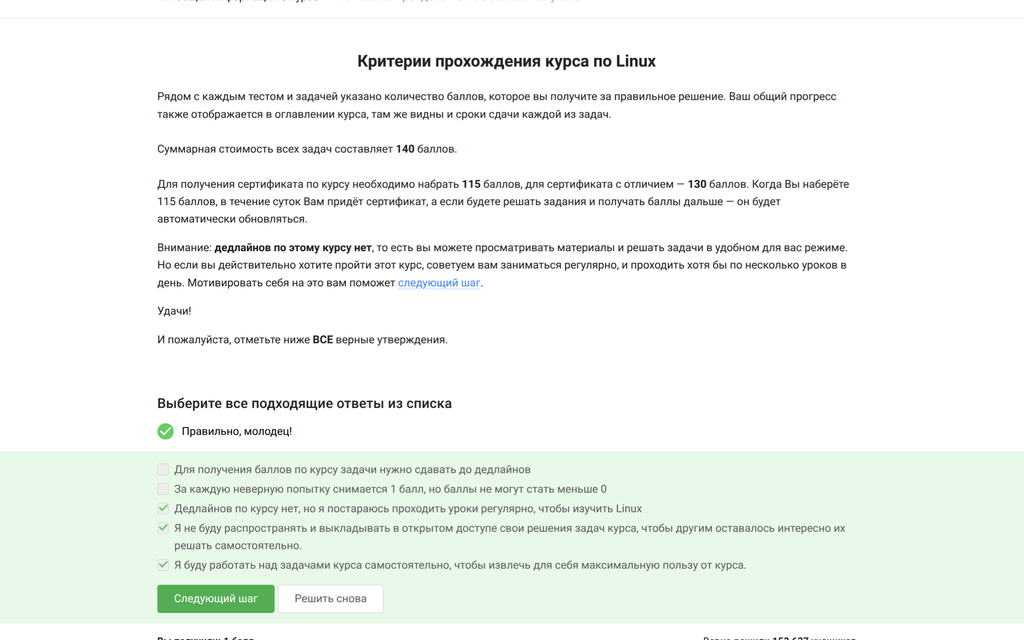

Общая информация

# Как установить Linux

Выбираю систему Windows, так как в повседневной жизни пользуюсь ей.

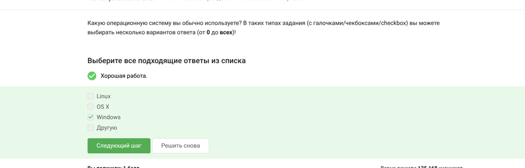

Выбор ОС

Виртуальная машина позволяет запустить ОС внутри основной системы.

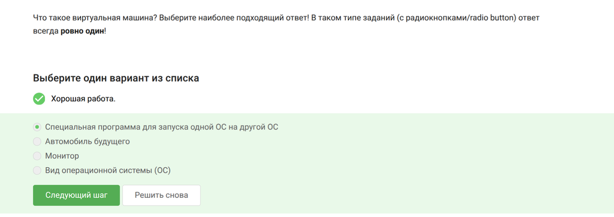

Понятие виртуальной машины

Ответил «да», так как уже пользовался системой Linux.

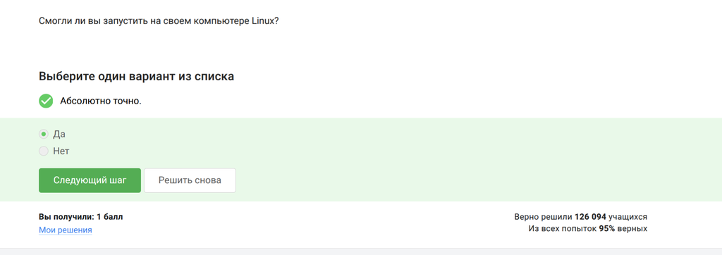

Вопрос об опыте использования Linux

# Осваиваем Linux

Создаю XML-файл со строкой Hello, Linux! в LibreOffice Writer.

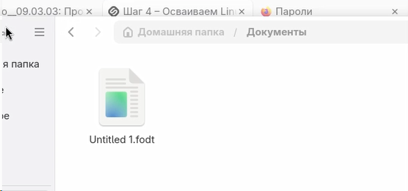

Создание файла

В Ubuntu пакеты имеют расширение deb.

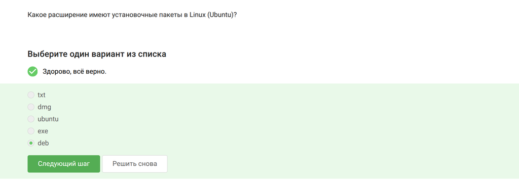

Пакеты в Ubuntu

Первая фамилия в списке авторов VLC — Denis-Courmont.

[figure not shown]

VLC media player

# Terminal: основы

Update Manager нужен для обновлений системы и программ. Выбираю подходящие ответы.

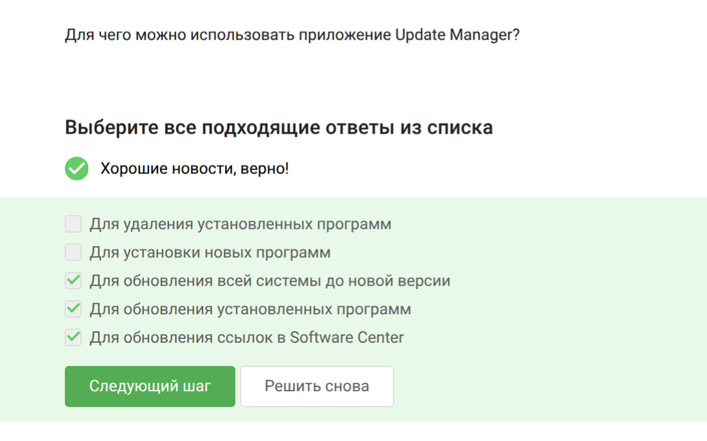

Update Manager

Терминал, консоль и командная строка — синонимы.

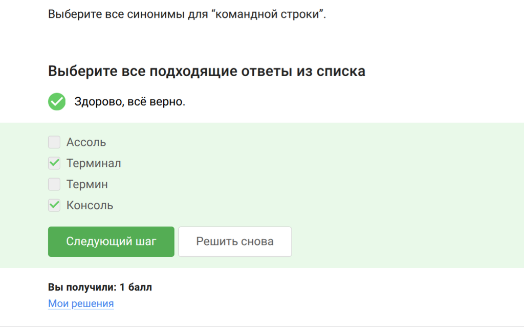

Синонимы командной строки

Только `pwd` (маленькими буквами) показывает текущую папку.

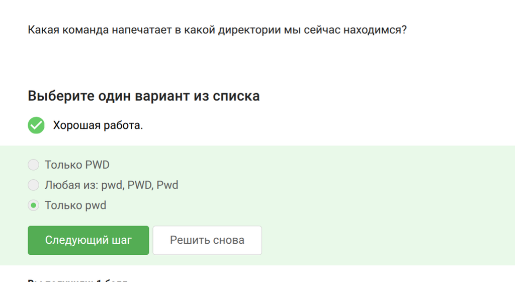

Команда pwd

Все варианты эквивалентны, порядок опций не важен.

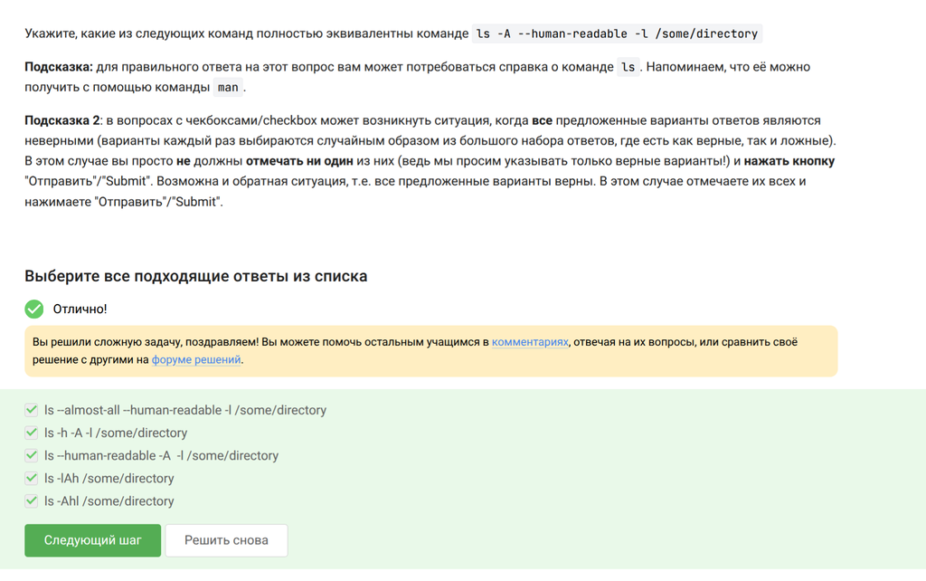

Эквивалентные команды ls

Директории удаляются командой `rm -r`.

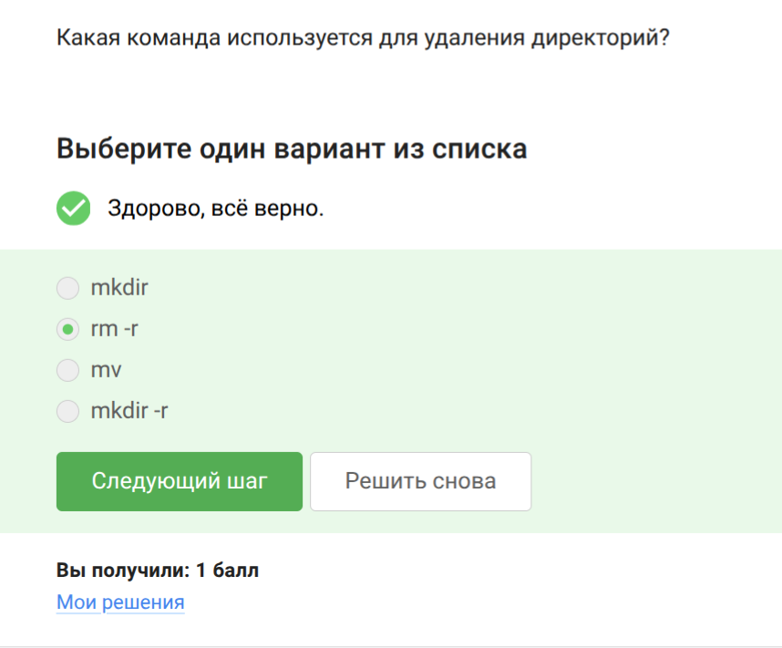

Удаление директорий

# Запуск исполняемых файлов

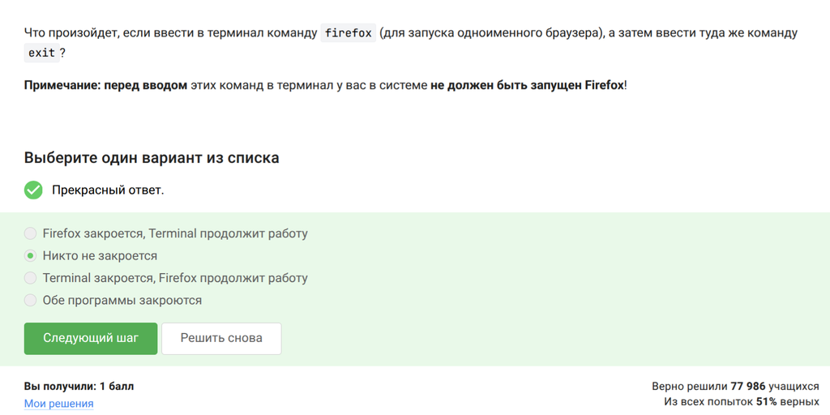

Запуск Firefox и exit

`&` эквивалентен запуску, затем `Ctrl+Z`, потом `bg`.

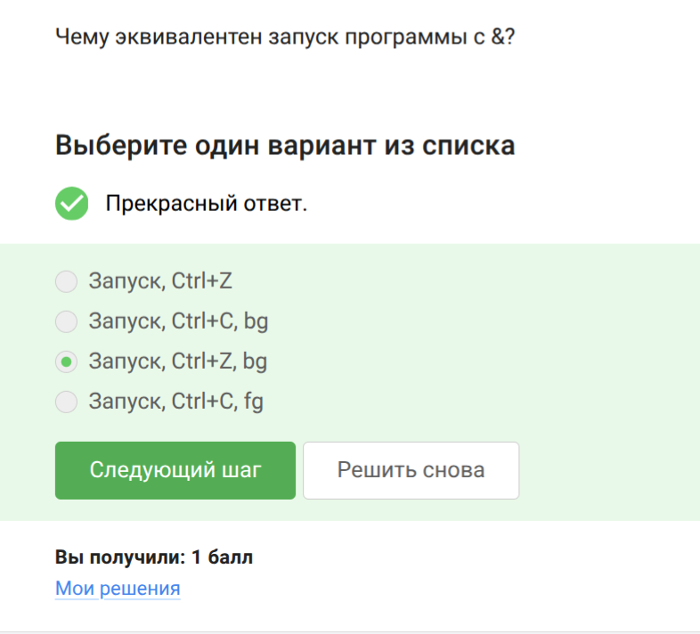

Фоновый запуск

Скрипт вывел дату и контрольную сумму 954.

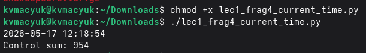

Результат работы скрипта

# Ввод / Вывод

Ошибки (stderr) по умолчанию выводятся на экран.

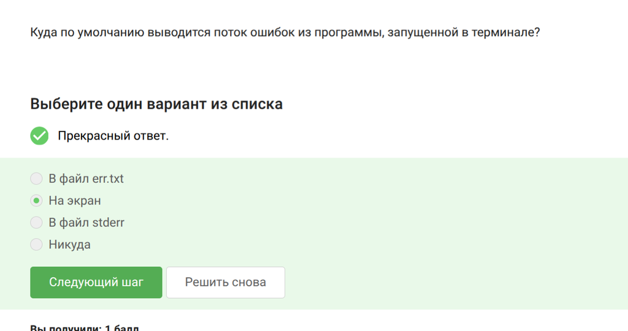

Вывод ошибок

Надо использовать `2>` или `2>>` для перенаправления ошибок.

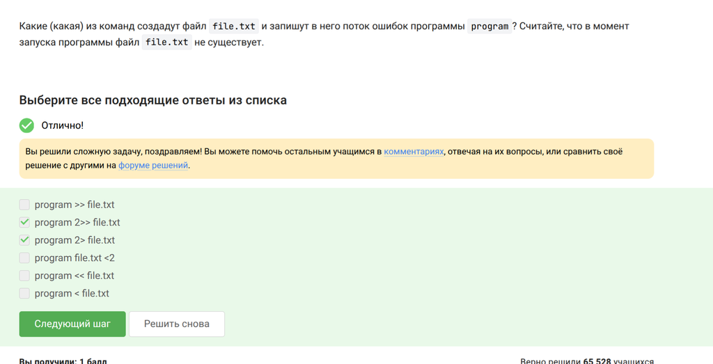

Перенаправление stderr

В конвейере (pipe) ошибки всё равно идут на экран.

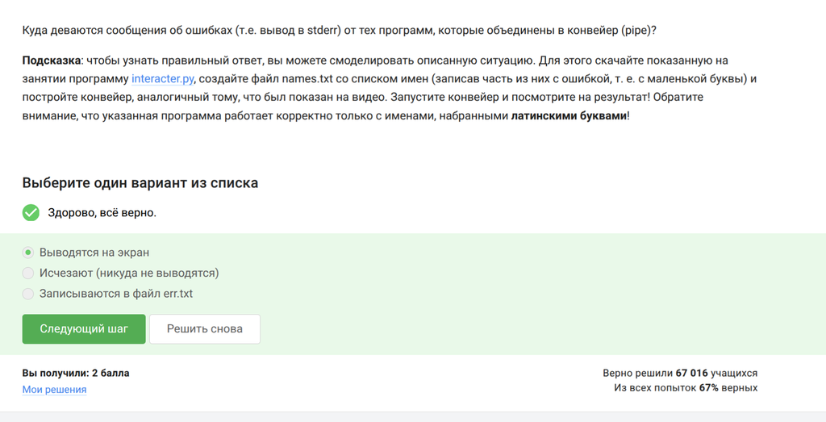

Ошибки в конвейере

# Скачивание файлов

Файл сохранится как `/home/alex/1.jpg`.

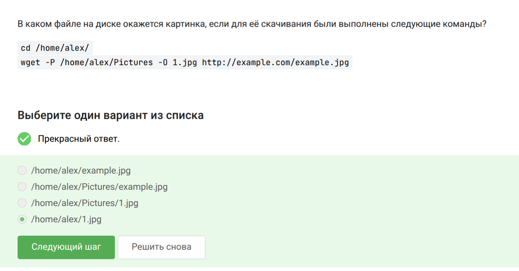

Сохранение файла wget

Опция `-q` (quiet) подавляет вывод сообщений.

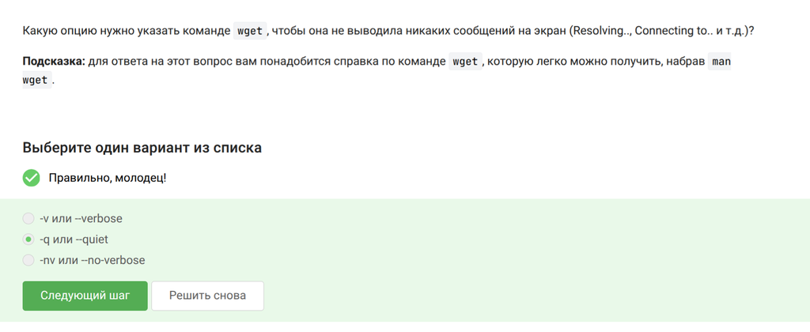

Тихий режим wget

Скачаются jpg и html, но html потом удалятся.

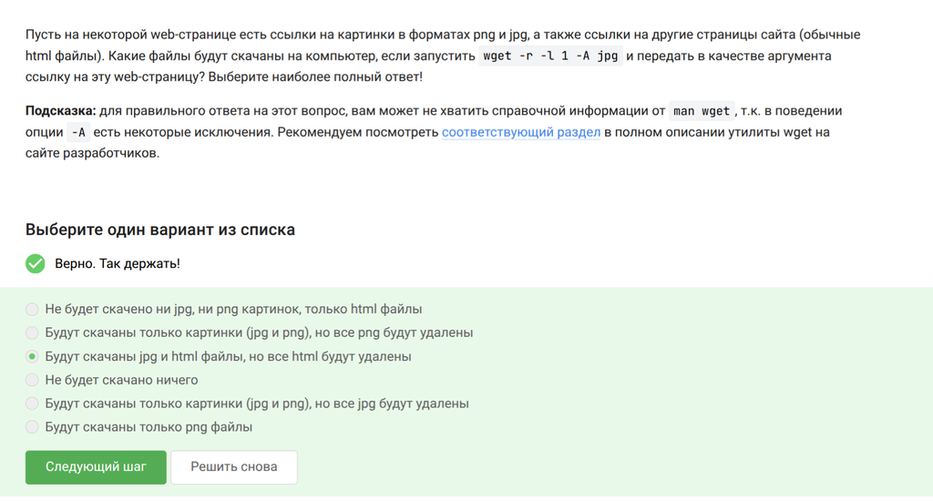

Рекурсивная загрузка

# Работа с архивами

`gzip` удаляет исходный архив после распаковки.

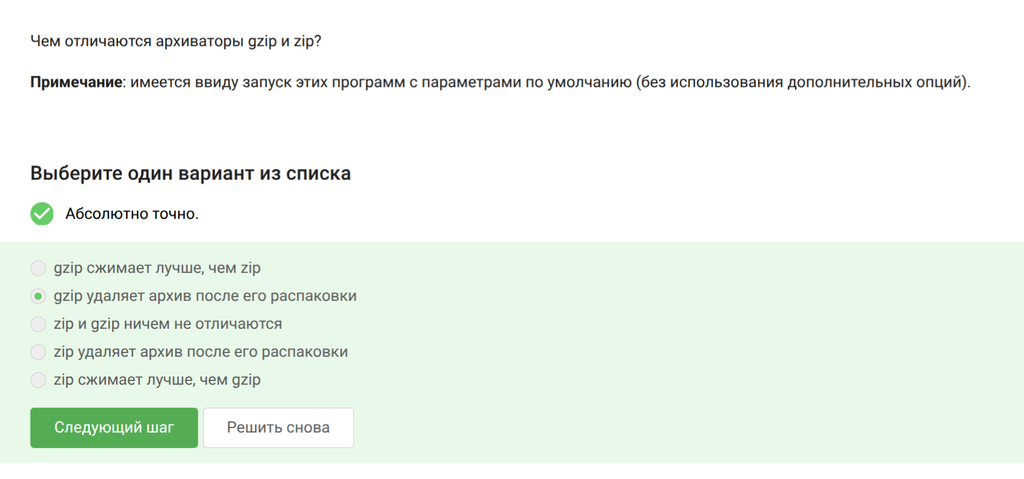

Отличие gzip от zip

`tar` и `zip` могут упаковать целую папку.

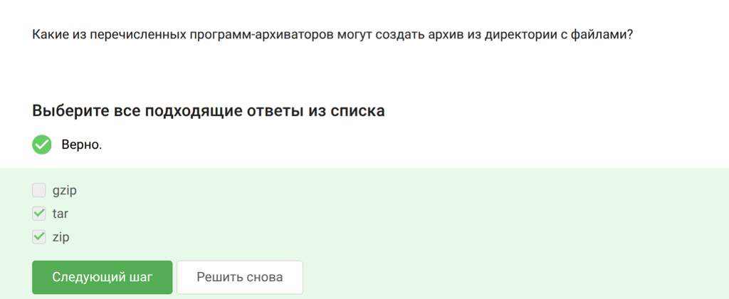

Архивация папок

Для `.tar.bz2` нужны опции `-cjf`.

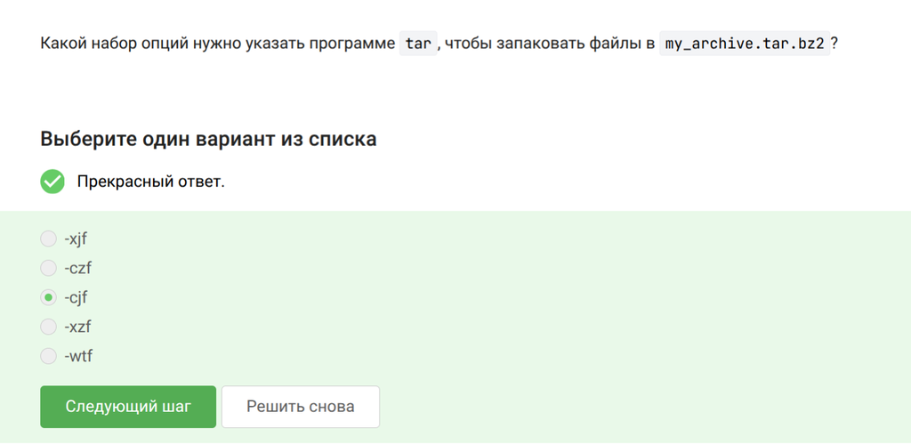

Создание tar.bz2

# Поиск файлов и слов в файлах

Маски `alexey.*` и `*.jpg` не найдут `Alexey.jpeg`.

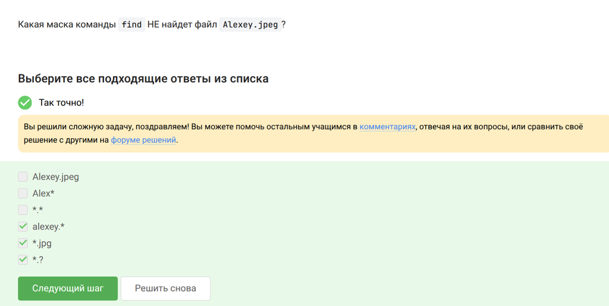

Поиск по маске

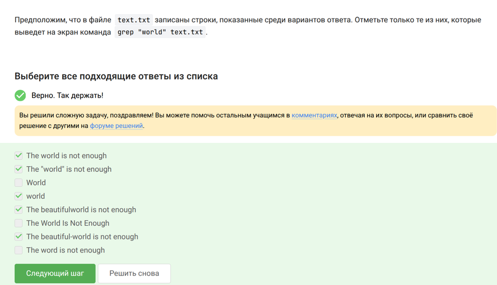

Поиск слова grep

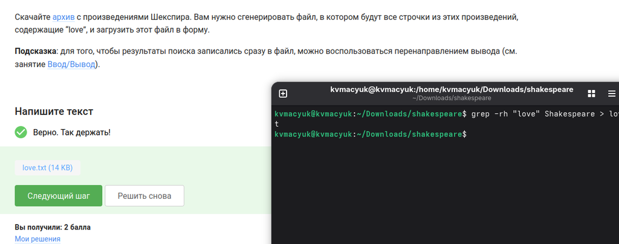

Поиск слова love в файлах

# Выводы

Прошел модуль 1 курса Stepik «Введение в Linux» и повторил основную информацию о работе в консоли.

# Список литературы